# P5_Underreporting_Pfizer_Covid_Vaccine

#### 4.4.4.1 Model 5: Best Model according to best subset method

We will fit the Model that was found to be the best above:

```r
lm5 <- pfi_event_dates_13 %>% lm(case_per_dose ~ Week + perc_2nd_dose, data = .)
summary(lm5)
```

```
##
## Call:
## lm(formula = case_per_dose ~ Week + perc_2nd_dose, data = .)
##
## Residuals:
##        Min         1Q     Median         3Q        Max
## -1.171e-06 -2.728e-07 -1.068e-08  2.405e-07  1.214e-06
##
## Coefficients:
##                 Estimate Std. Error t value Pr(>|t|)
## (Intercept)    2.637e-06  1.865e-07  14.134  < 2e-16 ***
## Week          -4.613e-08  4.919e-09  -9.377 1.99e-12 ***
## perc_2nd_dose -7.978e-09  3.678e-09  -2.169   0.0351 *
## ---
## Signif. codes:  0 '***' 0.001 '**' 0.01 '*' 0.05 '.' 0.1 ' ' 1
##
## Residual standard error: 5.113e-07 on 48 degrees of freedom
## Multiple R-squared:  0.6777, Adjusted R-squared:  0.6643
## F-statistic: 50.47 on 2 and 48 DF,  p-value: 1.576e-12
```

Adjusted R squared improved slightly (as was also predicted by the regsubsets function above). The Variable Percentage 2nd dose is now indicated to contribute significantly to the model.

**Check Model assumptions**

- Normality of Residuals:

Plot a histogram of the residuals:

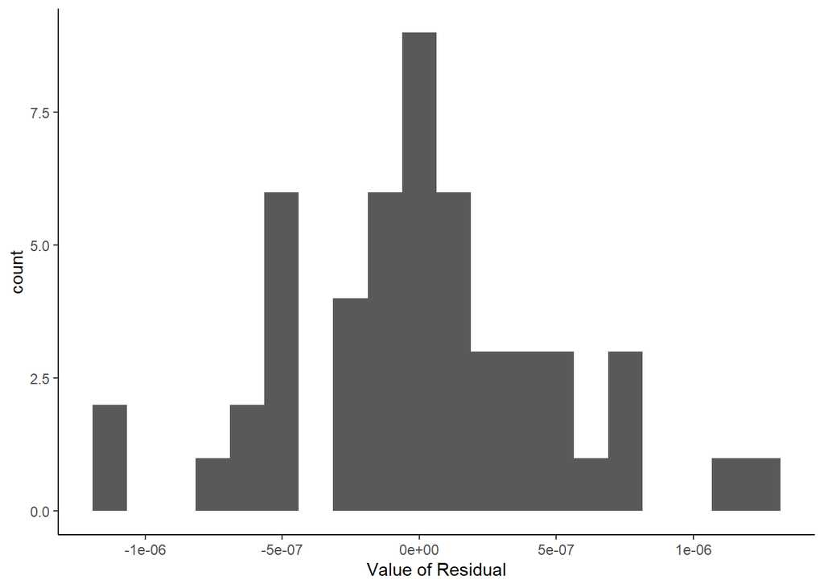

```r
residuals(lm5) %>% data.frame() %>% ggplot(aes(x = .)) +
    geom_histogram(bins = 20) +
    xlab(label = "Value of Residual") +
    theme_classic()
```

The distribution looks better then when all variables where included and outliers not yet excluded (at least its more symmetric).

- Consistent Variance over the range of the observations:

Produce a scatter plot for the fitted values vs the residuals

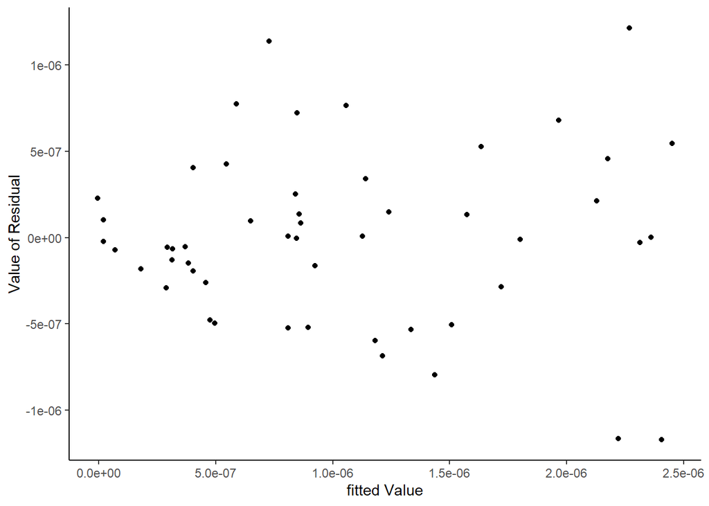

```r
lm5 %>% ggplot(aes(x = fitted(lm5), y = residuals(lm5))) +
    geom_point() +
    xlab(label = "fitted Value") +
    ylab(label = "Value of Residual") +
    theme_classic()
```

This plot looks better as well then for the model we last checked it for.

- Correlation between independent variables:

As we had previously already found, there is no correlation between the two variables used to fit this model:

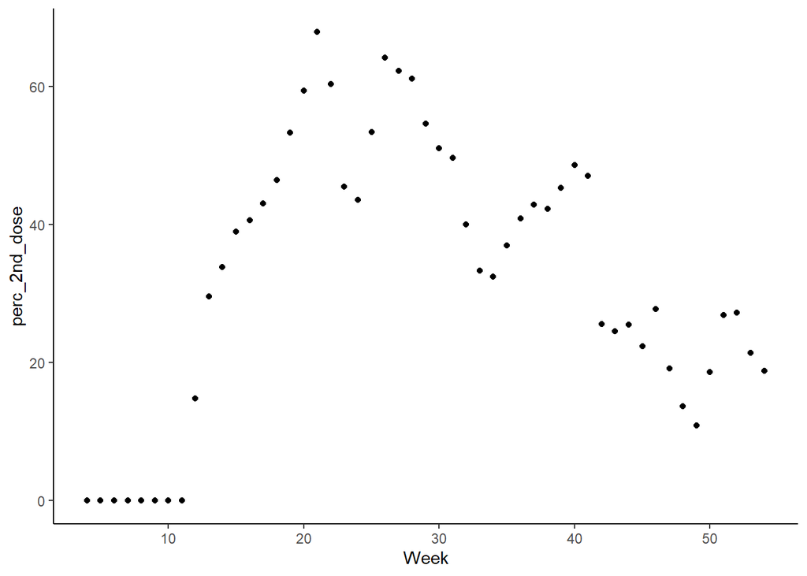

```r
pfi_event_dates_13 %>% ggplot(aes(x = Week, y = perc_2nd_dose)) +
    geom_point() +
    theme_classic()
```

### 4.4.5 Exponential Models

As previously discussed, there are problems when using a linear model, to fit cases per dose over time (as it will predict values < 0 after a certain point).  
Therefore I will now try to fit the model using the natural logarithm of case per dose. The reason being that the relationship between the logarithm of a dependent variable and time is linear, if there is an exponential relationship between this variable and time.

Plot log of case per dose vs. time and case per dose vs. time:

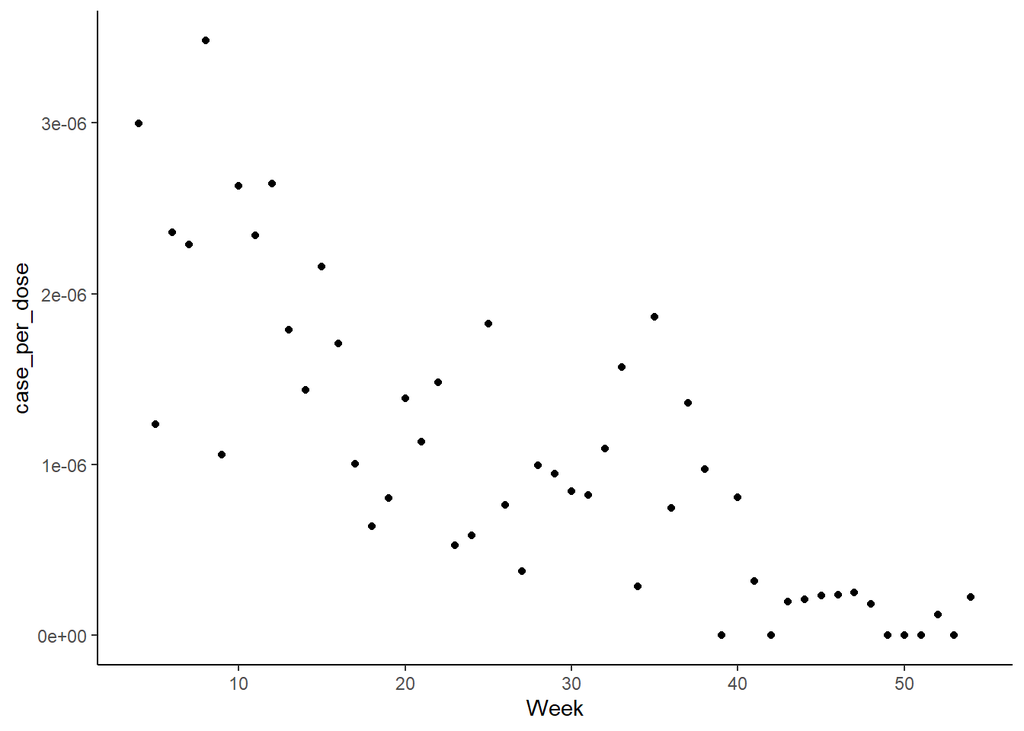

```r
pfi_event_dates_13 %>% ggplot(aes(x = Week, y = case_per_dose)) +
    geom_point() +
    theme_classic()
```

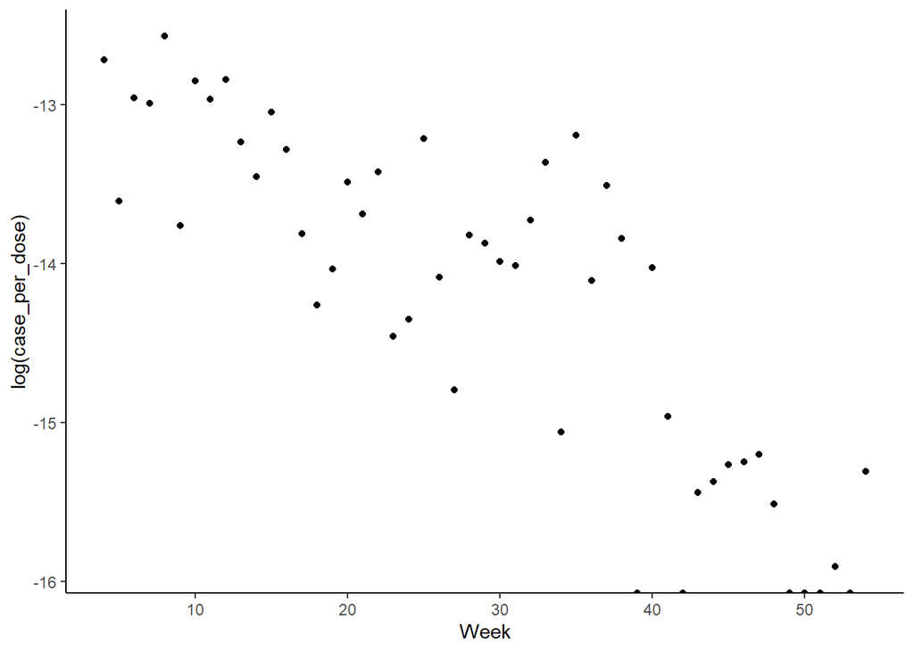

```r
pfi_event_dates_13 %>% ggplot(aes(x = Week, y = log(case_per_dose))) +
    geom_point() +
    theme_classic()
```

We see that if we take the logarithm of zero the result is -inf (if we approach from the positive side). This would lead to problems in the model fit.

#### 4.4.5.1 Model 6: Multiple Exponential Model

We will fit a model including the two dependent variables selected before, but to the transforemed (by log(x)) dependent variable. We will just exclude the zero values for now.  
Create dataframe with logarithm of cases per dose and records with zero value excluded:

```r
pfi_event_dates_14 <- pfi_event_dates_13 %>% mutate(log_c = log(case_per_dose)) %>% filter(log_c != -Inf)

em1 <- pfi_event_dates_14 %>% lm(log_c ~ Week + perc_2nd_dose, data = .)
summary(em1)
```

```
##
## Call:
## lm(formula = log_c ~ Week + perc_2nd_dose, data = .)
##
## Residuals:
##      Min       1Q   Median       3Q      Max
## -0.89240 -0.37411  0.05398  0.29831  1.21205
##
## Coefficients:
##                 Estimate Std. Error t value Pr(>|t|)
## (Intercept)   -12.673598   0.189361 -66.928  < 2e-16 ***
## Week           -0.052742   0.005764  -9.151 1.48e-11 ***
## perc_2nd_dose   0.003115   0.003914   0.796    0.431
## ---
## Signif. codes:  0 '***' 0.001 '**' 0.01 '*' 0.05 '.' 0.1 ' ' 1
##
## Residual standard error: 0.5151 on 42 degrees of freedom
## Multiple R-squared:  0.6737, Adjusted R-squared:  0.6582
## F-statistic: 43.37 on 2 and 42 DF,  p-value: 6.09e-11
```

This decreases the adjusted R squared slightly. It is probably also not very good to just exclude these values, as we introduce some bias and loose some records that might have helped the model.

While time and case per dose seem to have an exponential relationship. This doesnt seem to be the case between percentage second dose and case per dose.

#### 4.4.5.2 Model 7: Simple Exponential Model

Does taking the logarithm improve the fit between the case per dose and time?

```r
em2 <- pfi_event_dates_14 %>% lm(case_per_dose ~ Week, data = .)
summary(em2)
```

```
##
## Call:
## lm(formula = case_per_dose ~ Week, data = .)
##
## Residuals:
##        Min         1Q     Median         3Q        Max
## -9.382e-07 -2.981e-07 -1.261e-08  3.157e-07  1.447e-06
##
## Coefficients:
##               Estimate Std. Error t value Pr(>|t|)
## (Intercept)  2.404e-06  1.790e-07   13.43  < 2e-16 ***
## Week        -4.620e-08  5.977e-09   -7.73 1.15e-09 ***
## ---
## Signif. codes:  0 '***' 0.001 '**' 0.01 '*' 0.05 '.' 0.1 ' ' 1
##
## Residual standard error: 5.547e-07 on 43 degrees of freedom
## Multiple R-squared:  0.5815, Adjusted R-squared:  0.5718
## F-statistic: 59.75 on 1 and 43 DF,  p-value: 1.149e-09
```

```r
em3 <- pfi_event_dates_14 %>% lm(log_c ~ Week, data = .)
summary(em3)
```

```
##
## Call:
## lm(formula = log_c ~ Week, data = .)
##
## Residuals:
##      Min       1Q   Median       3Q      Max
## -0.80398 -0.43920  0.03794  0.31185  1.21168
##
## Coefficients:
##               Estimate Std. Error t value Pr(>|t|)
## (Intercept) -12.601390   0.165500 -76.141  < 2e-16 ***
## Week         -0.051508   0.005527  -9.319 7.02e-12 ***
## ---
## Signif. codes:  0 '***' 0.001 '**' 0.01 '*' 0.05 '.' 0.1 ' ' 1
##
## Residual standard error: 0.5129 on 43 degrees of freedom
## Multiple R-squared:  0.6688, Adjusted R-squared:  0.6611
## F-statistic: 86.84 on 1 and 43 DF,  p-value: 7.023e-12
```

Yes the R squared value is better (0.6611 vs. 0.5718) for the model usign the logarithm of the dependent variable.

It is about the same as for the previous model, that used two variables.

The disadvantage is that the model becomes harder to interpret, when looking at the results like that. We get a model for ln(case per dose), which doesnt mean much like this.

However we can transform the value,s to get the model for case per dose.

Now our model has the following form:
$$ln(y) = a + bx$$
Therefore to get the model to predict y, we take the exponential funtion of both sides, to get:
$$y = e^{a + bx}$$
Therefore we get our model fit as:
$$case\_per\_dose = e^{-12.6-0.05x} = 3.4*10^{-6}*e^{-0.05x}$$
$3.4*10^{-6}$ represents the y intercept (at week 0) while the 0.05 in the exponent describes the curvature of the model.
NOTE: This model was fit only on data starting in week 4, since we had excluded the weeks before earlier. It would make more sense to set the first record as week 0.

Plot the model:

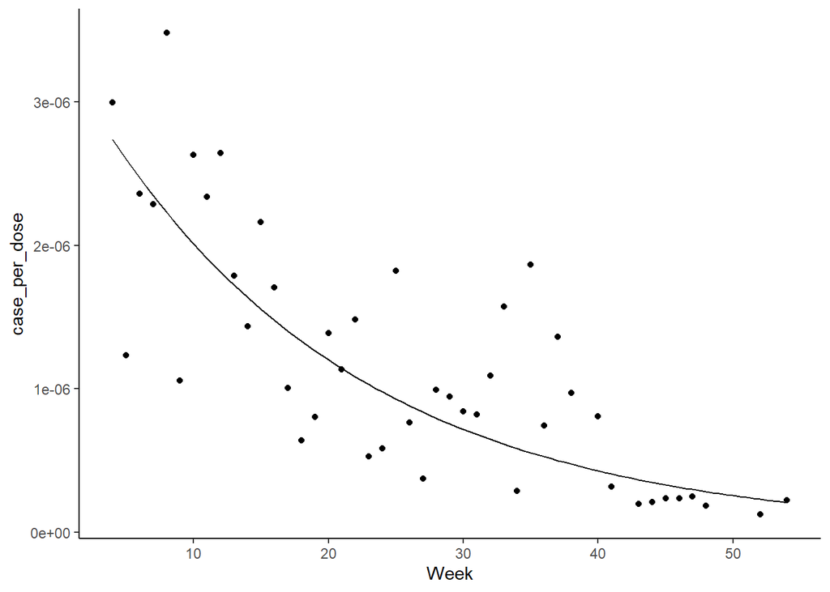

```r
pfi_event_dates_14 %>% ggplot(aes(x = Week, y = case_per_dose)) +
    geom_point()+
    geom_function(fun = function(x) 3.3673*10^(-6)*exp(-0.0515*x)) +
    theme_classic()
```

It is possible that the fit after week 40 is to high because we removed the 0 values.

**check Model assumptions**

- Normality of Residuals:

Plot a histogram of the residuals:

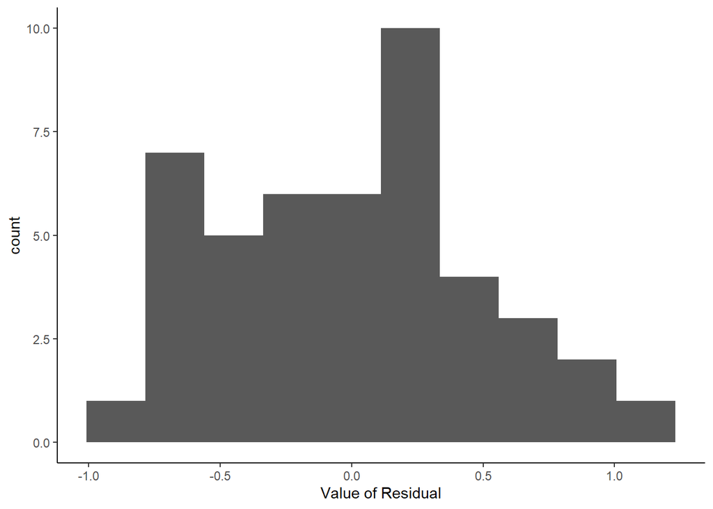

```r
residuals(em3) %>% data.frame() %>% ggplot(aes(x = .)) +
    geom_histogram(bins = 10) +
    xlab(label = "Value of Residual") +
    theme_classic()
```

The distribution seems to be a bit right skewed.

- Consistent Variance over the range of the observations:

Produce a scatter plot for the fitted values vs the residuals

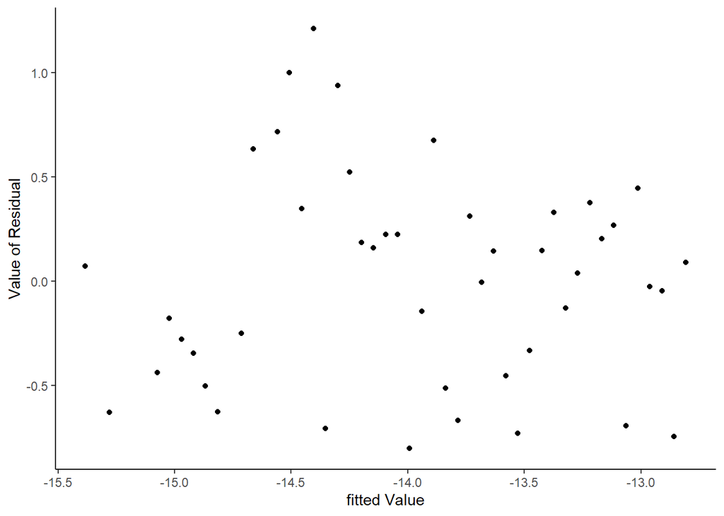

```r
em3 %>% ggplot(aes(x = fitted(em3), y = residuals(em3))) +
    geom_point() +
    xlab(label = "fitted Value") +
    ylab(label = "Value of Residual") +
    theme_classic()
```

There is no visible tendency of more variance on one side.

#### 4.4.5.3 Dealing with 0s in the dependent variable

Instead of just leaving out the records where case per dose is 0 we will now try different techniques that will allow us to leave them in.  
We will try the following “solutions” for this problem:  
- instead of log(x) use log(x+1)  
- assign very small value instead of 0  
- increase the size of the bins (from one to two/three weeks)

#### 4.4.5.4 Model 8: Use log(x+1) instead of log(x)

NOTE: We will include again all the data we have (meaning also the first four weeks, which we had previously excluded because they contained outliers, that where identified when using a multiple linear regression model)

Create dataframe:

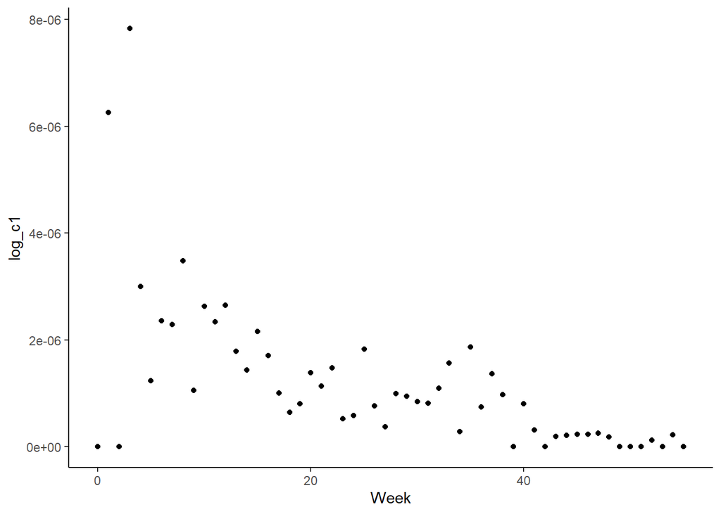

```r
pfi_event_dates_15 <- pfi_event_dates_11 %>% select(Week, case_per_dose)
#add log(x+1*10^(-7)); I chose to add a value that is close to the smallest value in the data:
pfi_event_dates_15 <- pfi_event_dates_15 %>% mutate(log_c1 = log(case_per_dose+1))
#plot
pfi_event_dates_15 %>% ggplot(aes(x = Week, y = log_c1)) +
    geom_point() +
    theme_classic()
```

Fit the model:

```r
em4 <- pfi_event_dates_15 %>% lm(log_c1 ~ Week, data = .)
summary(em4)
```

```
##
## Call:
## lm(formula = log_c1 ~ Week, data = .)
##
## Residuals:
##        Min         1Q     Median         3Q        Max
## -2.711e-06 -4.408e-07 -1.970e-08  2.817e-07  5.283e-06
##
## Coefficients:
##               Estimate Std. Error t value Pr(>|t|)
## (Intercept)  2.711e-06  2.998e-07   9.044 2.11e-12 ***
## Week        -5.506e-08  9.398e-09  -5.859 2.87e-07 ***
## ---
## Signif. codes:  0 '***' 0.001 '**' 0.01 '*' 0.05 '.' 0.1 ' ' 1
##
## Residual standard error: 1.137e-06 on 54 degrees of freedom
## Multiple R-squared:  0.3886, Adjusted R-squared:  0.3773
## F-statistic: 34.32 on 1 and 54 DF,  p-value: 2.87e-07
```

The adjusted R-squared is low compared to the last model.

Lets see if the fit improves much when we again exclude the first four weeks from the model:

```r
em5 <- pfi_event_dates_15[5:56,] %>% lm(log_c1 ~ Week, data = .)
summary(em5)
```

```
##
## Call:
## lm(formula = log_c1 ~ Week, data = .)
##
## Residuals:
##        Min         1Q     Median         3Q        Max
## -9.422e-07 -2.923e-07 -4.920e-09  2.452e-07  1.447e-06
##
## Coefficients:
##               Estimate Std. Error t value Pr(>|t|)
## (Intercept)  2.413e-06  1.608e-07  15.009  < 2e-16 ***
## Week        -4.728e-08  4.857e-09  -9.733 3.96e-13 ***
## ---
## Signif. codes:  0 '***' 0.001 '**' 0.01 '*' 0.05 '.' 0.1 ' ' 1
##
## Residual standard error: 5.257e-07 on 50 degrees of freedom
## Multiple R-squared:  0.6545, Adjusted R-squared:  0.6476
## F-statistic: 94.74 on 1 and 50 DF,  p-value: 3.961e-13
```

Yes this is quite good (Adjusted R-squared: 0.64)

The resulting adjusted R squared is comparable with the model where we left out the 0 values.

**Check Model assumptions**

- Normality of Residuals:

Plot a histogram of the residuals:

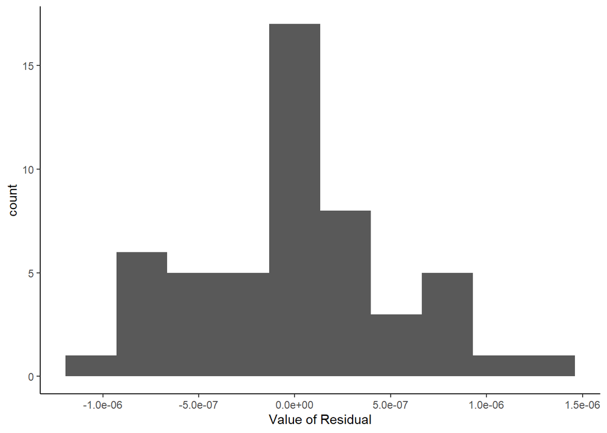

```r
residuals(em5) %>% data.frame() %>% ggplot(aes(x = .)) +
    geom_histogram(bins = 10) +
    xlab(label = "Value of Residual") +
    theme_classic()
```

The distribution seems to be a bit right skewed like in the model where we omitted the zero values.

We can use the Shapiro-Wilk test to test if we can exclude that the data comes from a normal distribution:

```r
shapiro.test(residuals(em5))
```

```
##
##  Shapiro-Wilk normality test
##
## data:  residuals(em5)
## W = 0.97482, p-value = 0.3344
```

A p-value >0.05 means we where not able to exclude that the data comes from a norma distribution.

- Consistent Variance over the range of the observations:

Produce a scatter plot for the fitted values vs the residuals

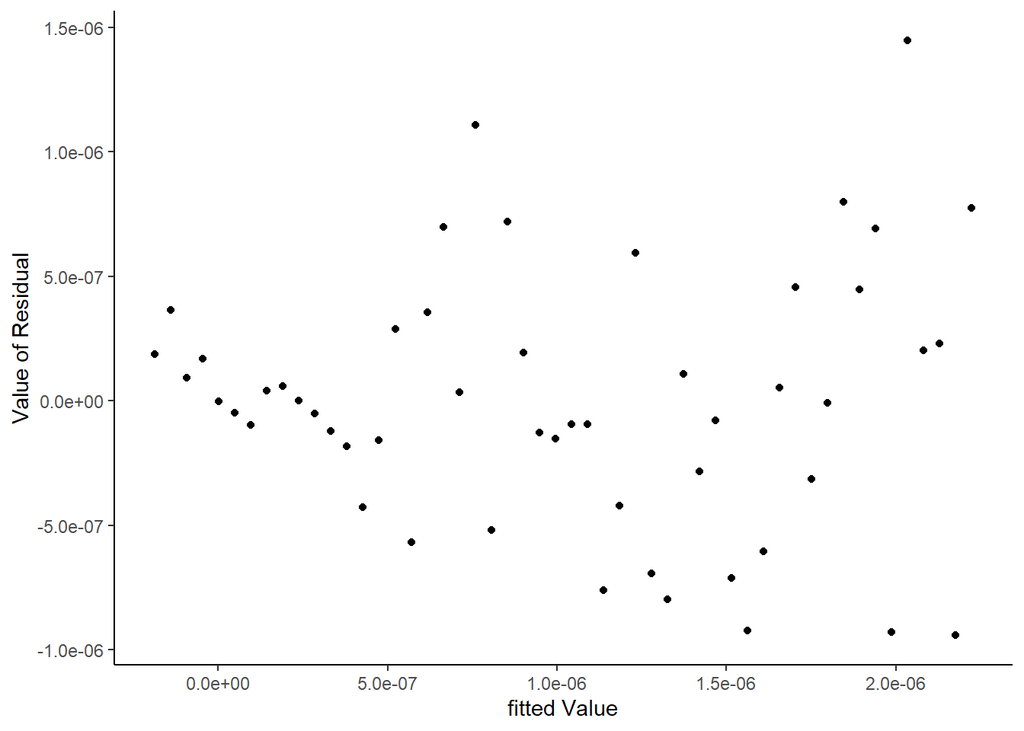

```r
em5 %>% ggplot(aes(x = fitted(em5), y = residuals(em5))) +
    geom_point() +
    xlab(label = "fitted Value") +
    ylab(label = "Value of Residual") +
    theme_classic()
```

There is less variance in the smaller fitted values. This is because we have several weeks with just either one or zero cases, so the only variance comes from the difference in dosages administered, which doesnt change drastically within a few weeks.  
It is also important to note that also taking the logarithm of cases per dose doesnt “get rid” of this problem, meaning that for this period, there is also less variance, when looking at it relative to the value of case per dose.

Lets look at a plot of fitted values vs. the squareroot of standardized residuals:

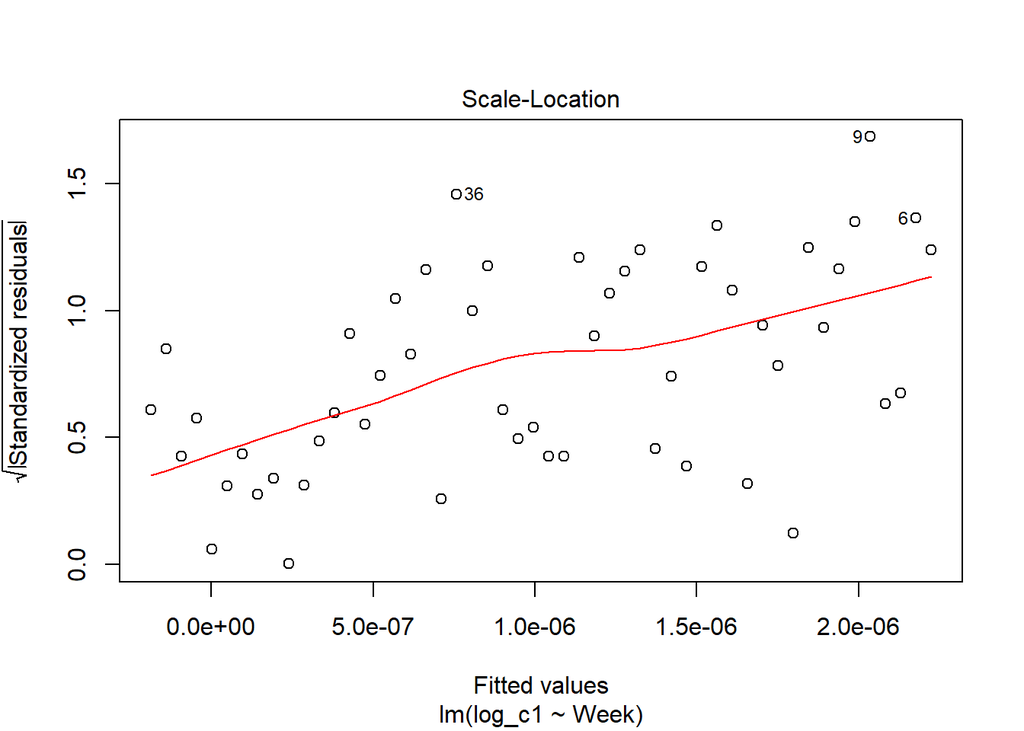

```r
plot(em5, 3)
```

The red line increases clearly to the right, telling us that there is more variability in higher fitted values meaning the data is heteroscedastic.  
Therefore the model assumptions are not met here and the result of the model might not be reliable.

#### 4.4.5.5 Model 9: Assign a very small value instead of 0.

Create new dataframe: (We will again exclude the first four datapoints and start the index for the weeks at 0)

```r
pfi_event_dates_16 <- pfi_event_dates_15[5:56, 2] %>% cbind(case_per_dose = ., Week = c(0:51)) %>% data.frame()
```

Replace the zeros by small values. We will try several different values to see if the choice of the value has an influence on the model.

```r
#1e-8
pfi_event_dates_16 <- pfi_event_dates_16 %>% cbind(., cpd_8 = pfi_event_dates_16$case_per_dose)
pfi_event_dates_16[pfi_event_dates_16$cpd_8 == 0, "cpd_8"] <- 1e-8
#1e-9
pfi_event_dates_16 <- pfi_event_dates_16 %>% cbind(., cpd_9 = pfi_event_dates_16$case_per_dose)
pfi_event_dates_16[pfi_event_dates_16$cpd_9 == 0, "cpd_9"] <- 1e-9
#1e-10
pfi_event_dates_16 <- pfi_event_dates_16 %>% cbind(., cpd_10 = pfi_event_dates_16$case_per_dose)
pfi_event_dates_16[pfi_event_dates_16$cpd_10 == 0, "cpd_10"] <- 1e-10
#calculate log
pfi_event_dates_16 <- pfi_event_dates_16 %>% mutate(., log_8 = log(cpd_8), log_9 = log(cpd_9), log_10 = log(cpd_10))
```

Fit the models

```r
em6 <- pfi_event_dates_16 %>% lm(log_8 ~ Week, data = .)
summary(em6)
```

```
##
## Call:
## lm(formula = log_8 ~ Week, data = .)
##
## Residuals:
##     Min      1Q  Median      3Q     Max
## -3.0141 -0.4161  0.1520  0.6754  1.8612
##
## Coefficients:
##              Estimate Std. Error t value Pr(>|t|)
## (Intercept) -12.31875    0.30696 -40.132  < 2e-16 ***
## Week         -0.08822    0.01037  -8.504 2.79e-11 ***
## ---
## Signif. codes:  0 '***' 0.001 '**' 0.01 '*' 0.05 '.' 0.1 ' ' 1
##
## Residual standard error: 1.123 on 50 degrees of freedom
## Multiple R-squared:  0.5912, Adjusted R-squared:  0.5831
## F-statistic: 72.32 on 1 and 50 DF,  p-value: 2.789e-11
```

```r
em7 <- pfi_event_dates_16 %>% lm(log_9 ~ Week, data = .)
summary(em7)
```

```
##
## Call:
## lm(formula = log_9 ~ Week, data = .)
##
## Residuals:
##     Min      1Q  Median      3Q     Max
## -4.7593 -0.4405  0.1975  1.2677  2.3681
##
## Coefficients:
##             Estimate Std. Error t value Pr(>|t|)
## (Intercept) -11.9645     0.4853 -24.654  < 2e-16 ***
## Week         -0.1143     0.0164  -6.967 6.76e-09 ***
## ---
## Signif. codes:  0 '***' 0.001 '**' 0.01 '*' 0.05 '.' 0.1 ' ' 1
##
## Residual standard error: 1.775 on 50 degrees of freedom
## Multiple R-squared:  0.4926, Adjusted R-squared:  0.4824
## F-statistic: 48.54 on 1 and 50 DF,  p-value: 6.758e-09
```

```r
em8 <- pfi_event_dates_16 %>% lm(log_10 ~ Week, data = .)
summary(em8)
```

```
##
## Call:
## lm(formula = log_10 ~ Week, data = .)
##
## Residuals:
##     Min      1Q  Median      3Q     Max
## -6.5045 -0.5014  0.2079  1.8414  3.3163
##
## Coefficients:
##              Estimate Std. Error t value Pr(>|t|)
## (Intercept) -11.61026    0.67014 -17.325  < 2e-16 ***
## Week         -0.14032    0.02265  -6.196 1.09e-07 ***
## ---
## Signif. codes:  0 '***' 0.001 '**' 0.01 '*' 0.05 '.' 0.1 ' ' 1
##
## Residual standard error: 2.451 on 50 degrees of freedom
## Multiple R-squared:  0.4343, Adjusted R-squared:  0.423
## F-statistic: 38.38 on 1 and 50 DF,  p-value: 1.086e-07
```

We see that the adjusted R squared decreases with a decreasing “replacing value”.

I am unsure which would be the most reasonable choice here. It seems like the outcome, when using this model is quite arbitrary, depending on the choice of the “replacing value”. Therefore I would avoid using this method.

#### 4.4.5.6 Model 10: Change the bin size to two weeks

We will now change the size of the bins from one week to two weeks. Like this we can get rid of all but one zero values in our data.  
Create the dataframe:

```r
#create indicator to distinguish odd and even rows
odd_rows <- seq_len(nrow(pfi_event_dates_7)) %% 2
#separate dataframe into even and odd rows
pfi_event_dates_7_or <- pfi_event_dates_7[odd_rows == 1, ]
pfi_event_dates_7_er <- pfi_event_dates_7[odd_rows == 0, ]
#bind them together
pfi_event_dates_17 <- cbind(pfi_event_dates_7_or[, c("nr_adm_pw", "count_cases")], pfi_event_dates_7_er[, c("nr_adm_pw", "count_cases")])
colnames(pfi_event_dates_17) <- c("nr_adm_pw_o", "count_cases_o", "nr_adm_pw_e", "count_cases_e")
#add the even and odd rows together, which gives us the totals for two subsequent weeks
pfi_event_dates_17 <- pfi_event_dates_17 %>% transmute(nr_adm_pw = nr_adm_pw_o + nr_adm_pw_e, count_cases = count_cases_o + count_cases_e) %>%
    cbind(., time_index = c(0:27))
#calculate case per dose
pfi_event_dates_18 <- pfi_event_dates_17 %>% mutate(case_per_dose = count_cases/nr_adm_pw) %>%
    select(time_index, case_per_dose)
```

Plot the new data binned per two weeks:

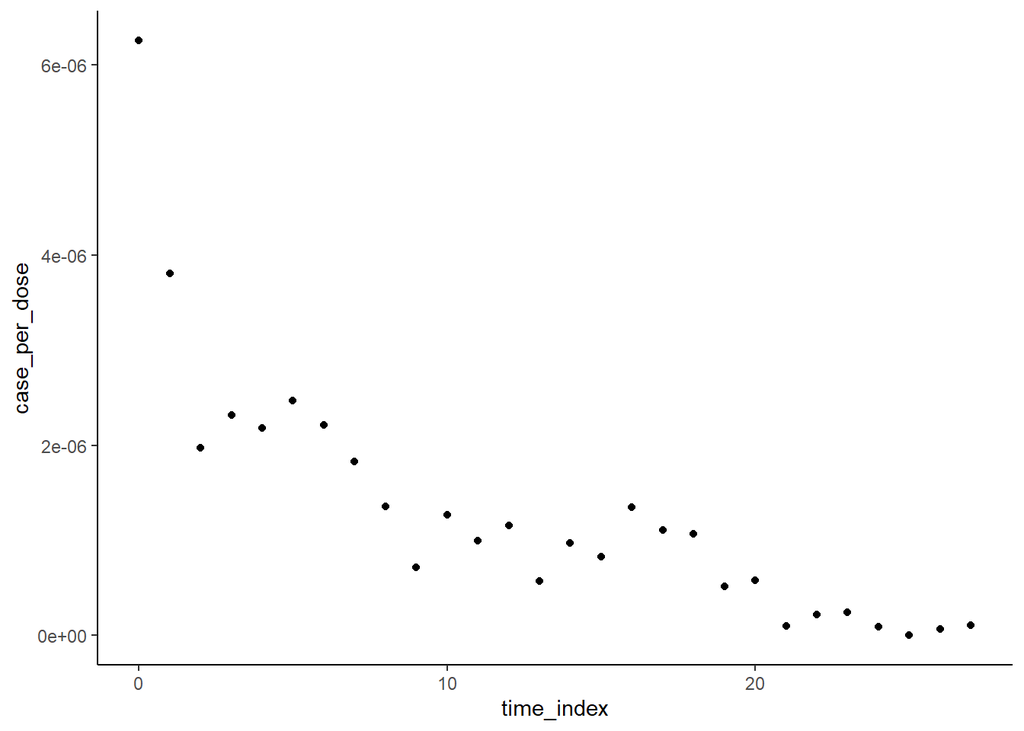

```r
pfi_event_dates_18 %>% ggplot(aes(x = time_index, y = case_per_dose)) +
    geom_point() +
    theme_classic()
```

The records for the first four weeks still look extreme, but they might fit in an exponential decay curve.

Drop the remaining record with a zero value and calculate log:

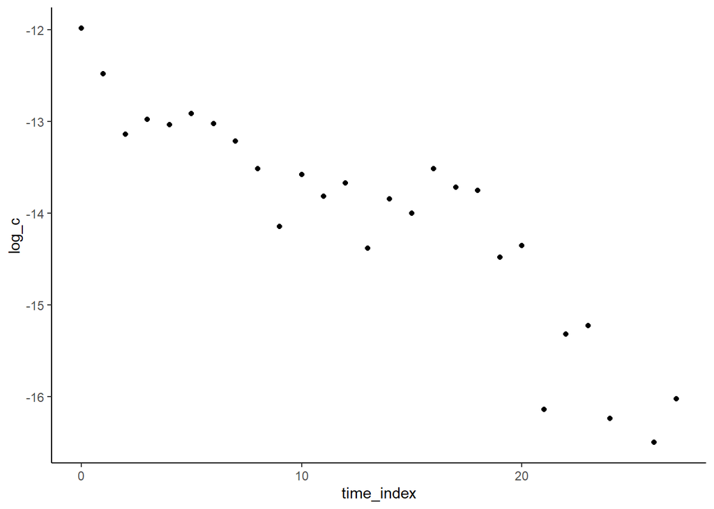

```r
pfi_event_dates_19 <- pfi_event_dates_18 %>% filter(case_per_dose != 0) %>%
    mutate(log_c = log(case_per_dose))

#plot the log
pfi_event_dates_19 %>% ggplot(aes(x = time_index, y = log_c)) +
    geom_point() +
    theme_classic()
```

Now it looks like the first four weeks blend in with the rest of the data mor or less.

Fit the model:

```r
em9 <- pfi_event_dates_19 %>% lm(log_c ~ time_index, data = .)
summary(em9)
```

```
##
## Call:
## lm(formula = log_c ~ time_index, data = .)
##
## Residuals:
##      Min       1Q   Median       3Q      Max
## -1.04892 -0.24408  0.01494  0.30253  0.94234
##
## Coefficients:
##              Estimate Std. Error t value Pr(>|t|)
## (Intercept) -12.29520    0.19020  -64.64  < 2e-16 ***
## time_index   -0.13315    0.01245  -10.70 8.07e-11 ***
## ---
## Signif. codes:  0 '***' 0.001 '**' 0.01 '*' 0.05 '.' 0.1 ' ' 1
##
## Residual standard error: 0.5116 on 25 degrees of freedom
## Multiple R-squared:  0.8207, Adjusted R-squared:  0.8136
## F-statistic: 114.4 on 1 and 25 DF,  p-value: 8.075e-11
```

This improved the model quite a bit. I think the reason for this is probably that by making the bin size bigger, we can get rid of some of the variance in the data, which is there because there are not that many cases reported, which has a similar effect as having a small sample, meaning there is a lot of variation by chance.  
A good example for this is that the data for the first 4 weeks went from being outliers (identified via the cooks distance) to fitting in quite well. The reason being that the high values of weeks 2 and 4 where “averaged together” with the zero values of Weeks 1 and 3 respectively.

Plot the model:  
- linear fit to log(case_per_dose)

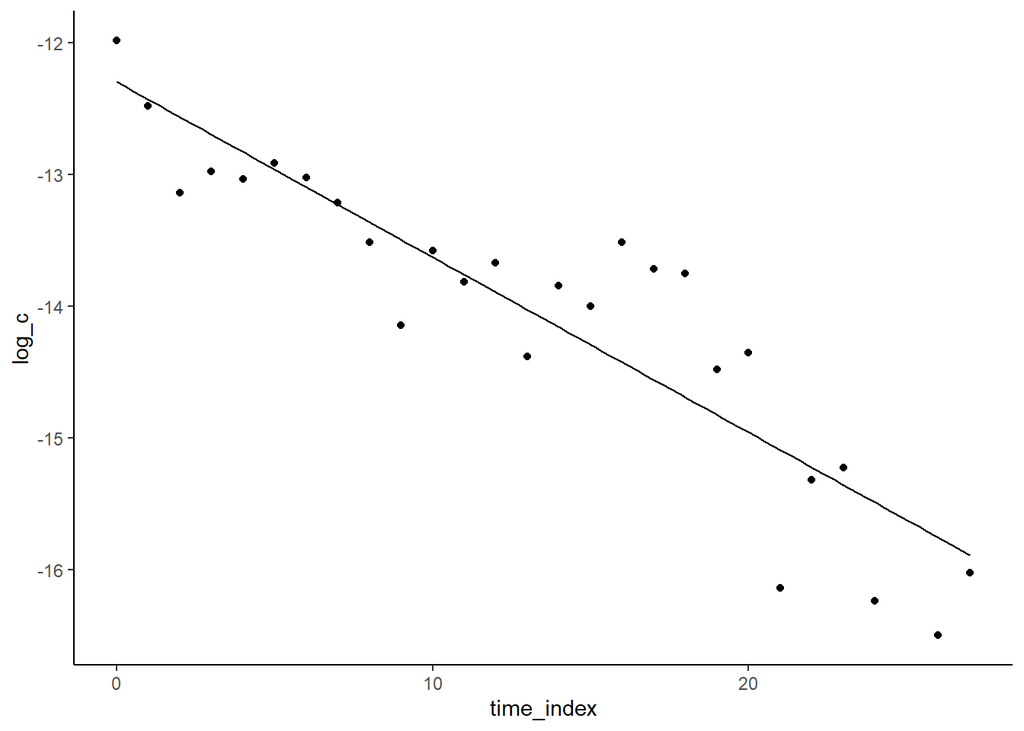

```r
pfi_event_dates_19 %>% ggplot(aes(x = time_index, y = log_c)) +
    geom_point()+
    geom_function(fun = function(x) -12.29520 - 0.13315*x) +
    theme_classic()
```

- The exponential curve to case_per_dose

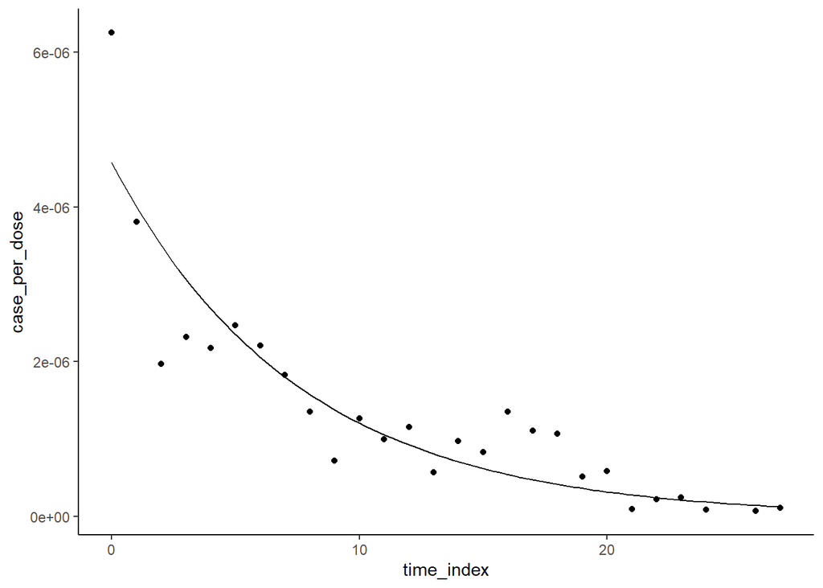

```r
pfi_event_dates_19 %>% ggplot(aes(x = time_index, y = case_per_dose)) +
    geom_point()+
    geom_function(fun = function(x) 4.573645e-06*exp(-0.13315*x)) +
    theme_classic()
```

**check Model assumptions**

- Normality of Residuals:

Plot a histogram of the residuals:

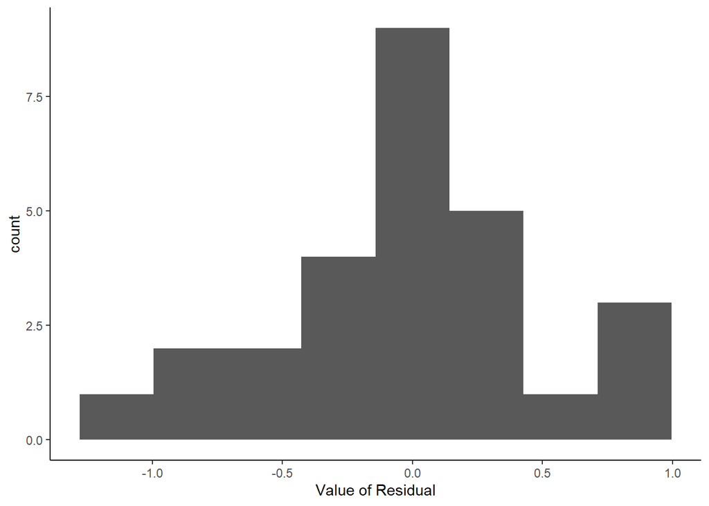

```r
residuals(em9) %>% data.frame() %>% ggplot(aes(x = .)) +
    geom_histogram(bins = 8) +
    xlab(label = "Value of Residual") +
    theme_classic()
```

Looks ok, maybe a bit left skewed.

Perform Shapiro-Wilk test:

```r
shapiro.test(residuals(em9))
```

```
##
##  Shapiro-Wilk normality test
##
## data:  residuals(em9)
## W = 0.97254, p-value = 0.67
```

We cannot exclude normality of the residuals here. However, now we only have a sample size of 27 which is not ideal for the performance of the test.

- Consistent Variance over the range of the observations:

Produce a scatter plot for the fitted values vs the residuals

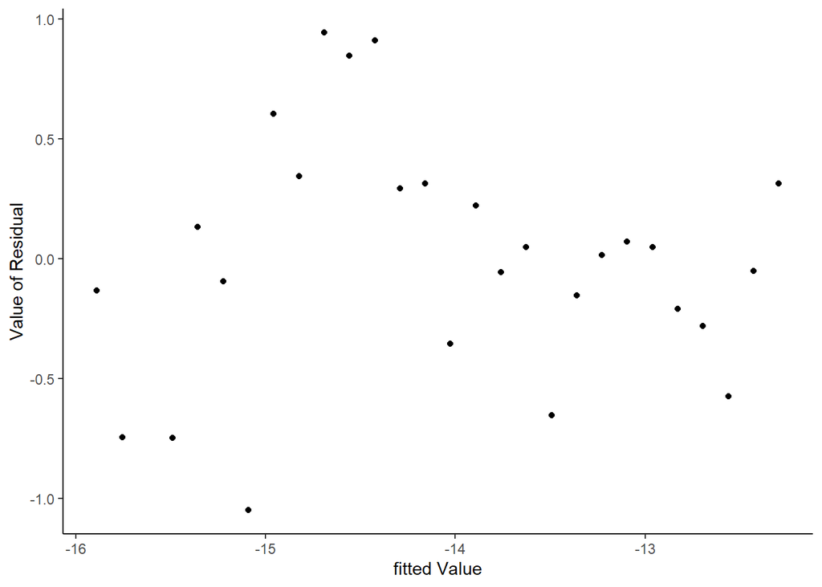

```r
em9 %>% ggplot(aes(x = fitted(em9), y = residuals(em9))) +
    geom_point() +
    xlab(label = "fitted Value") +
    ylab(label = "Value of Residual") +
    theme_classic()
```

Seems more or less consistent, maybe a bit more variance in the lower fitted values.

Plot the fitted value versus the squareroot of the standardized residuals:

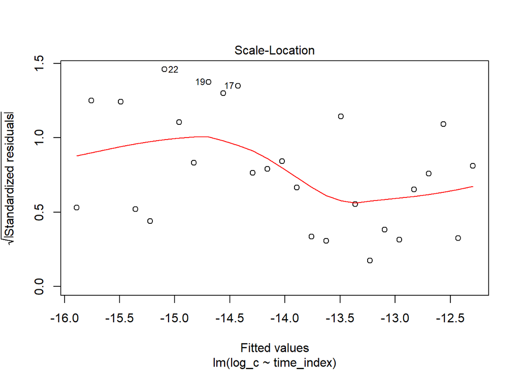

```r
plot(em9, 3)
```

The red line shows no clear tendency. Its not perfect but I dont think this violates the model assumptions.

We can therefore more or less trust the results of this model.

#### 4.4.5.7 Model 11: Increasing Bin size to three Weeks

Since we are still excluding one data point, we will again try to increase the bin size to three weeks.

Create the dataframe:

```r
#create indicator to distinguish between three weeks
three_w <- seq_len(nrow(pfi_event_dates_7)) %% 3
#separate dataframe into even and odd rows
pfi_event_dates_7_1 <- pfi_event_dates_7[three_w == 1, ]
pfi_event_dates_7_2 <- pfi_event_dates_7[three_w == 2, ]
pfi_event_dates_7_3 <- pfi_event_dates_7[three_w == 0, ]
#the groups contain 18, 19, 19 records => we have to drop two weeks
#bind them together
pfi_event_dates_20 <- cbind(pfi_event_dates_7_1[1:18, c("nr_adm_pw", "count_cases")],
                            pfi_event_dates_7_2[1:18, c("nr_adm_pw", "count_cases")],
                            pfi_event_dates_7_3[, c("nr_adm_pw", "count_cases")])
colnames(pfi_event_dates_20) <- c("nr_adm_pw_1", "count_cases_1", "nr_adm_pw_2", "count_cases_2", "nr_adm_pw_3", "count_cases_3")
#add rows together, which gives us the totals for three subsequent weeks
pfi_event_dates_20 <- pfi_event_dates_20 %>% transmute(nr_adm_pw = nr_adm_pw_1 + nr_adm_pw_2 + nr_adm_pw_3, count_cases = count_cases_1 + count_cases_2 + count_cases_3) %>%
    cbind(., time_index = c(0:17))
#calculate case per dose
pfi_event_dates_20 <- pfi_event_dates_20 %>% mutate(case_per_dose = count_cases/nr_adm_pw) %>%
    select(time_index, case_per_dose)
```

Calculate log:

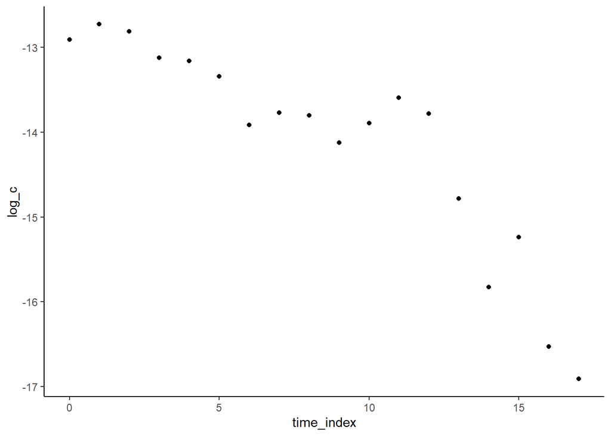

```r
pfi_event_dates_20 <- pfi_event_dates_20 %>%
    mutate(log_c = log(case_per_dose))

#plot the log
pfi_event_dates_20 %>% ggplot(aes(x = time_index, y = log_c)) +
    geom_point() +
    theme_classic()
```

```r
em10 <- pfi_event_dates_20 %>% lm(log_c ~ time_index, data = .)
summary(em10)
```

```
##
## Call:
## lm(formula = log_c ~ time_index, data = .)
##
## Residuals:
##      Min       1Q   Median       3Q      Max
## -1.00451 -0.27874  0.02994  0.24068  1.07851
##
## Coefficients:
##              Estimate Std. Error t value Pr(>|t|)
## (Intercept) -12.34065    0.25941 -47.573  < 2e-16 ***
## time_index   -0.20975    0.02605  -8.052  5.1e-07 ***
## ---
## Signif. codes:  0 '***' 0.001 '**' 0.01 '*' 0.05 '.' 0.1 ' ' 1
##
## Residual standard error: 0.5734 on 16 degrees of freedom
## Multiple R-squared:  0.8021, Adjusted R-squared:  0.7897
## F-statistic: 64.83 on 1 and 16 DF,  p-value: 5.099e-07
```

The adjusted r squared is a bit lower then for the model where we binned two weeks. This might be because we excluded some data (the last two weeks). However, given the choice between excluding data at the end of the period due to the number of weeks not being dividable by 3 or excluding data because its value is zero, leaving out the last two weeks is easier to justify, as it doesnt introduce any bias.

**Check Model Assumptions**

- Normality of Residuals:

Plot a histogram of the residuals:

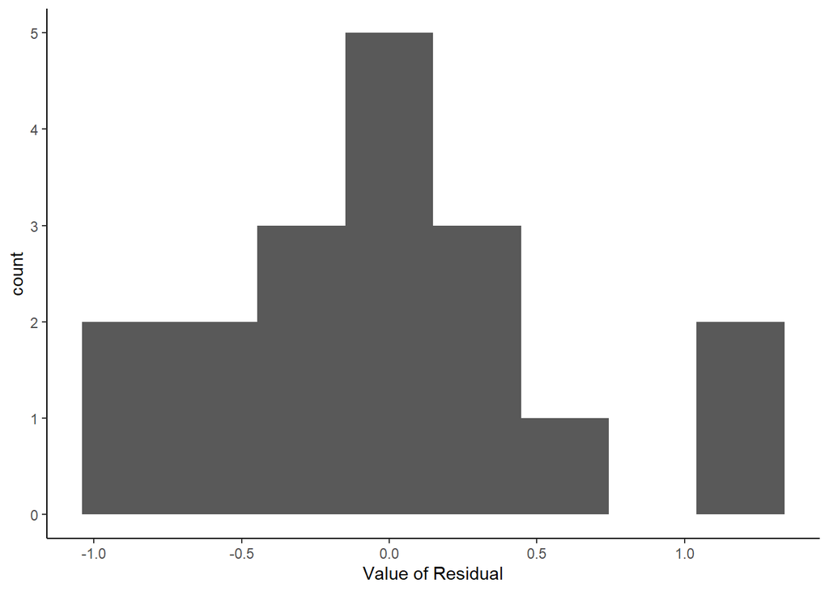

```r
residuals(em10) %>% data.frame() %>% ggplot(aes(x = .)) +
    geom_histogram(bins = 8) +
    xlab(label = "Value of Residual") +
    theme_classic()
```

Looks more or less ok.

Perform the Shapiro-Wilk test on the residuals:

```r
shapiro.test(residuals(em10))
```

```
##
##  Shapiro-Wilk normality test
##
## data:  residuals(em10)
## W = 0.96067, p-value = 0.6146
```

We cannot exclude normality here. However with only 18 samples the performance of this test is probably not ideal.

- Consistent Variance over the range of the observations:

Produce a scatter plot for the fitted values vs the residuals

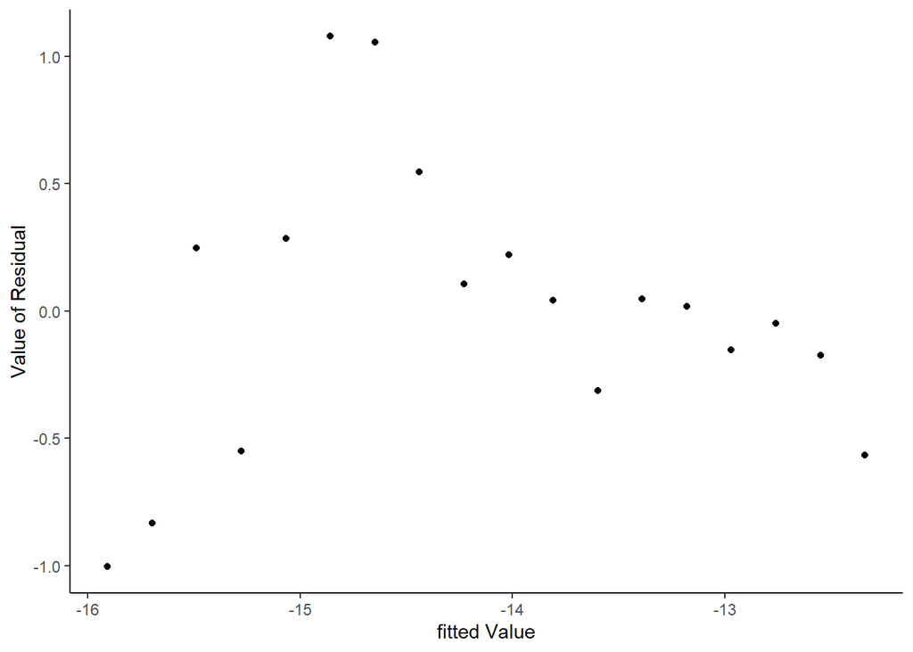

```r
em10 %>% ggplot(aes(x = fitted(em10), y = residuals(em10))) +
    geom_point() +
    xlab(label = "fitted Value") +
    ylab(label = "Value of Residual") +
    theme_classic()
```

There is more variance in the lower fitted values.

Plot the fitted values versus the squareroot of the standardized residuals:

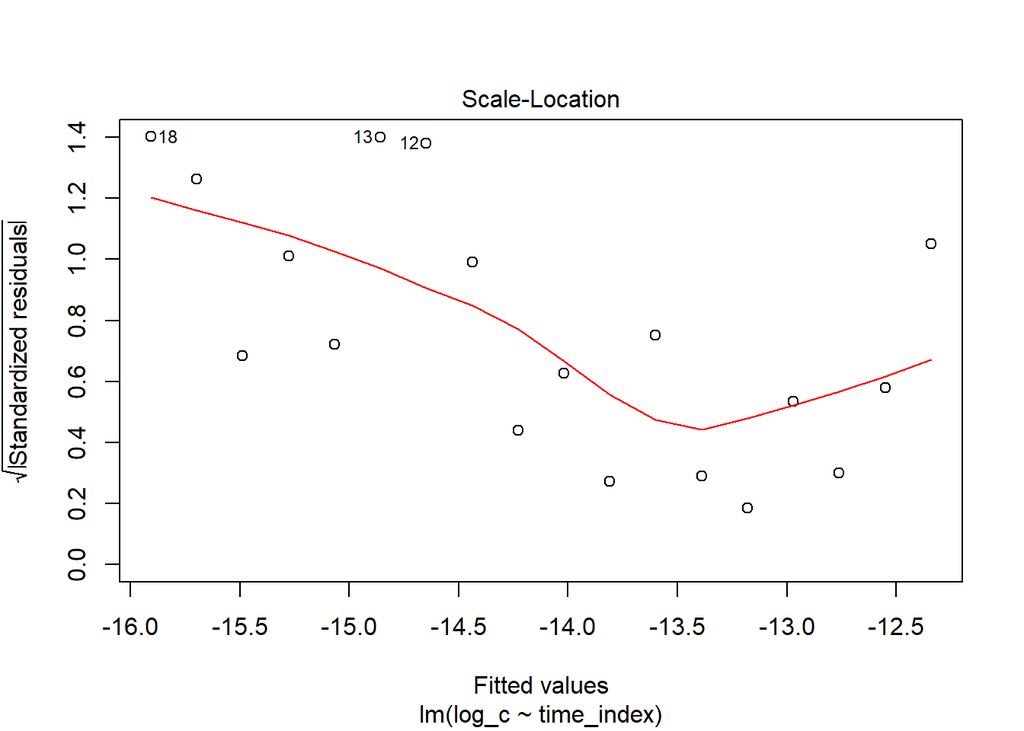

```r
plot(em10, 3)
```

There is no clear tendency overall, but the plot does not look ideal.

Due to the small sample size this model was fit on it is hard to say if the model assumptions are met. Therefore the model with binsize of two weeks is probably “better” then this one.

## 4.5 Discussion

### 4.5.1 Correlation With Case Per Dose

After fitting many models, the only plausible correlation with case per dose we found was with time. This could be explained as follows:  
- Public interest in the vaccines / ADRs of the vaccines, decreased over time and therefore also the number of reported events.  
- With time health professionals knew better, which ADRs where typical for the vaccine and reported them less often.  
- As the vaccines where on the market for longer, their safety profiles where better known and health professionals saw it as less important to report cases in order to improve it.

As previously discussed, the most plausible model for this relationship seems to be exponential decay, since the value cannot reach negative values, and the scatter plot makes this seem plausible as well.

However this model is of course only valid for the period where we have data and cannot be used to make predictions. This becomes obvious when we consider that the number of cases per dose could increase again for example due to media attention to a serious side effect of the vaccine.

### 4.5.2 Dealing With Zero Values In Exponential Models

The best solution for dealing with zeros, that we used here was probably to increase the size of the bins for the time variable, as like this we did not “manipulate” the data in any way (as we do with the other methods). The problem with this is however that we reduce the number of data points for the model, which can make it more difficult to assess if the model assumptions are met.  
The “sweet spot” for this data was probably a bin size of two weeks, since this got rid of some of the variability we had with a bin size of one week, but still allowed more or less to assess if the model assumptions are met.

### 4.5.3 Possible Further Investigations

- We could try to fit the same kind of model for the Moderna vaccine (for the Janssen vaccine we might not have enough data, as it was not administered as much.) in order to corroborate the results here.
- We could also extend the time period. (At the time of writing the data for the first quarter of 2022 is available)
- We could replicate what we did for other territories.
- It could be interesting to find other factors that might influence the reported cases per administered dose, such as media attention to the covid vaccine (which might be hard to quantify however).

### 4.5.4 Caveats

For many of the models, the model assumptions where not perfectly met, therefore the results might not be very reliable.

The variable we had taken to predict was calculated by dividing number of cases with event date per time over doses administered over time.  
This definitely makes the most sense if cases occur quickly after the administration. This is however not always the case.